*Load the libraries*

```r
library(ggplot2)
library(qqplotr)
library(psych)
library(dplyr)
library(e1071)
library(corrplot)
library(rcompanion)
library(RVAideMemoire)
library(multcomp)
library(report)
library(car)
library(caret)
library(stats)
library(forecast)
library(TTR)
```

*Load the dataset and check for the beginning and end of it*

```r
data=read.csv('datafinalless var - final.csv',header = T)
head(data)
```

```
##   Country_Name Country_Code Time Access_to_electricity._percentage_of_pop
## 1       Angola          AGO 2011                                 34.60000
## 2       Angola          AGO 2012                                 37.25949
## 3       Angola          AGO 2013                                 38.39818
## 4       Angola          AGO 2014                                 32.00000
## 5       Angola          AGO 2015                                 42.00000
## 6       Angola          AGO 2016                                 41.78503
##   Life_expectancy_at_birth Mortality_rate_under_5_per_1.000_live_births
## 1                   57.596                                        112.2
## 2                   58.623                                        104.9
## 3                   59.307                                         98.3
## 4                   60.040                                         92.9
## 5                   60.655                                         88.3
## 6                   61.092                                         84.4
##   Political_Stability.Absence_of_Violence.Terrorism._Percentile_R
```

[output cut: 20 more lines]

```r
tail(data)
```

```
##     Country_Name Country_Code Time Access_to_electricity._percentage_of_pop
## 115  New Zealand          NZL 2015                                      100
## 116  New Zealand          NZL 2016                                      100
## 117  New Zealand          NZL 2017                                      100
## 118  New Zealand          NZL 2018                                      100
## 119  New Zealand          NZL 2019                                      100
## 120  New Zealand          NZL 2020                                      100
##     Life_expectancy_at_birth Mortality_rate_under_5_per_1.000_live_births
## 115                 81.61244                                          5.5
## 116                 81.65854                                          5.3
## 117                 81.85854                                          5.2
## 118                 81.70732                                          5.0
## 119                 82.05610                                          4.9
## 120                 82.25610                                          4.8
##     Political_Stability.Absence_of_Violence.Terrorism._Percentile_R
```

[output cut: 20 more lines]

*Check for the columns names:*

```r
colnames(data)
```

```
##  [1] "Country_Name"
##  [2] "Country_Code"
##  [3] "Time"
##  [4] "Access_to_electricity._percentage_of_pop"
##  [5] "Life_expectancy_at_birth"
##  [6] "Mortality_rate_under_5_per_1.000_live_births"
##  [7] "Political_Stability.Absence_of_Violence.Terrorism._Percentile_R"
##  [8] "Population_total"
##  [9] "Real_interest_rate_perc"
## [10] "Consumer_price_index_2010._100"
## [11] "GDP_US."
```

```r
cat("\n")
```

```r
unique(data$Country.Name)
```

```r
cat("\n")
```

```r
unique(data$Time)
```

```
##  [1] 2011 2012 2013 2014 2015 2016 2017 2018 2019 2020
```

So we have 11 features, 12 country data over 10 years of time.

I will make some general descriptive statistics base on all of the variables that I’m considering

```r
summary(data)
```

```
##  Country_Name       Country_Code            Time
##  Length:120         Length:120         Min.   :2011
##  Class :character   Class :character   1st Qu.:2013
##  Mode  :character   Mode  :character   Median :2016
##                                        Mean   :2016
##                                        3rd Qu.:2018
##                                        Max.   :2020
##  Access_to_electricity._percentage_of_pop Life_expectancy_at_birth
##  Min.   : 12.90                           Min.   :57.60
##  1st Qu.: 89.93                           1st Qu.:71.55
##  Median :100.00                           Median :80.75
##  Mean   : 86.92                           Mean   :76.02
##  3rd Qu.:100.00                           3rd Qu.:82.23
##  Max.   :100.00                           Max.   :84.47
##  Mortality_rate_under_5_per_1.000_live_births
##  Min.   :  2.20
##  1st Qu.:  3.80
##  Median :  6.50
##  Mean   : 21.41
##  3rd Qu.: 22.68
##  Max.   :112.20
##  Political_Stability.Absence_of_Violence.Terrorism._Percentile_R
##  Min.   :19.43
##  1st Qu.:35.03
##  Median :59.86
##  Mean   :61.66
##  3rd Qu.:89.74
##  Max.   :99.52
##  Population_total    Real_interest_rate_perc Consumer_price_index_2010._100
##  Min.   :  4384000   Length:120              Min.   :101.3
##  1st Qu.: 14306072   Class :character        1st Qu.:108.5
##  Median : 26508042   Mode  :character        Median :114.2
##  Mean   : 41705032                           Mean   :129.8
##  3rd Qu.: 41616206                           3rd Qu.:130.0
##  Max.   :213196304                           Max.   :464.1
##     GDP_US.
##  Min.   :1.132e+10
##  1st Qu.:2.010e+11
##  Median :3.475e+11
##  Mean   :7.640e+11
##  3rd Qu.:1.535e+12
##  Max.   :2.620e+12
```

*here I check if the data has the right format*

```r
str(data)
```

```
## 'data.frame':    120 obs. of  11 variables:
##  $ Country_Name                                                   : chr  "Angola" "Angola" "Angola" "Angola" ...
##  $ Country_Code                                                   : chr  "AGO" "AGO" "AGO" "AGO" ...
##  $ Time                                                           : int  2011 2012 2013 2014 2015 2016 2017 2018 2019 2020 ...
##  $ Access_to_electricity._percentage_of_pop                       : num  34.6 37.3 38.4 32 42 ...
##  $ Life_expectancy_at_birth                                       : num  57.6 58.6 59.3 60 60.7 ...
##  $ Mortality_rate_under_5_per_1.000_live_births                   : num  112.2 104.9 98.3 92.9 88.3 ...
##  $ Political_Stability.Absence_of_Violence.Terrorism._Percentile_R: num  34.6 35.1 35.1 32.9 28.1 ...
##  $ Population_total                                               : int  24259111 25188292 26147002 27128337 28127721 29154746 30208628 31273533 32353588 33428486 ...
##  $ Real_interest_rate_perc                                        : chr  "-9.876356841" "8.764706246" "12.61080218" "12.38052977" ...
##  $ Consumer_price_index_2010._100                                 : num  113 125 136 146 160 ...
##  $ GDP_US.                                                        : num  1.09e+11 1.25e+11 1.33e+11 1.37e+11 8.72e+10 ...
```

Everything looks right apart from the variable Real interest rate which was passed as character. I’ll need it to be numerical.

```r
data$Real_interest_rate_perc=as.numeric(data$Real_interest_rate_perc)
str(data$Real_interest_rate_perc)
```

```
##  num [1:120] -9.88 8.76 12.61 12.38 21.14 ...
```

```r
data$Real_interest_rate_perc
```

```
##   [1] -9.87635684  8.76470625 12.61080218 12.38052977 21.14418153 -4.92206319
##   [7] -5.55263828 -5.84400335  0.09091879  8.02865685 38.15134299 48.03324402
##  [13] 50.76010320 49.90850314 47.14666449 46.84276933 52.43678815 43.48334496
##  [19] 39.87708944 42.71405656  3.27930122  3.88287300  2.50924550  3.56702763
##  [25]  3.66774283  3.27825168  4.64731549  6.10876006  5.24371093  1.90715126
##  [31] 32.83345951 26.58209053 18.49884442 22.40367244 33.83234397 40.69836145
##  [37] 41.71380787 33.10233425 31.90307275 21.19717969  5.58745776  9.22337834
##  [43]  6.84632644  2.12102531  0.53410050  0.98291325 -0.26265531  2.54731216
##  [49]          NA          NA 11.17808786 17.82002249 16.90330807 12.99478509
##  [55] 13.06382202 12.98525678 12.71220357 11.98867770 12.28326446  8.67616539
##  [61]  2.94466373  3.61919865  3.95121200  3.91764783  3.16786623  2.33532588
##  [67]  2.25808864  1.59483303  1.64891714  0.74539062          NA          NA
##  [73]  1.75202763  3.94314737  6.48637648  4.74390945 -1.03296138 -3.57596656
##  [79]  3.80513914  5.34941942  4.16049084  4.86057756  5.83621695  5.63232356
##  [85]  2.21015017  4.85771062  2.33763639  1.73405641  5.46266353  8.16666529
##  [91] -0.22815842  1.76541083  1.24099044  1.03526947  3.68401596  1.93140658
##  [97]  0.13162693          NA          NA          NA  1.41773892  5.09054952
## [103]  6.34251991  4.46059619  6.20622194  6.06270092  1.44803743  3.37003626
## [109]  1.64730609          NA  3.53582338  6.00782233  1.32132079  5.36570804
## [115]  4.27020927  2.61140987  1.20061660          NA          NA          NA
```

```r
str(data)
```

```
## 'data.frame':    120 obs. of  11 variables:
##  $ Country_Name                                                   : chr  "Angola" "Angola" "Angola" "Angola" ...
##  $ Country_Code                                                   : chr  "AGO" "AGO" "AGO" "AGO" ...
##  $ Time                                                           : int  2011 2012 2013 2014 2015 2016 2017 2018 2019 2020 ...
##  $ Access_to_electricity._percentage_of_pop                       : num  34.6 37.3 38.4 32 42 ...
##  $ Life_expectancy_at_birth                                       : num  57.6 58.6 59.3 60 60.7 ...
##  $ Mortality_rate_under_5_per_1.000_live_births                   : num  112.2 104.9 98.3 92.9 88.3 ...
##  $ Political_Stability.Absence_of_Violence.Terrorism._Percentile_R: num  34.6 35.1 35.1 32.9 28.1 ...
##  $ Population_total                                               : int  24259111 25188292 26147002 27128337 28127721 29154746 30208628 31273533 32353588 33428486 ...
##  $ Real_interest_rate_perc                                        : num  -9.88 8.76 12.61 12.38 21.14 ...
##  $ Consumer_price_index_2010._100                                 : num  113 125 136 146 160 ...
##  $ GDP_US.                                                        : num  1.09e+11 1.25e+11 1.33e+11 1.37e+11 8.72e+10 ...
```

*Next step is taking care of missing data. Let’s check which columns contain missing data:

```r
colSums(is.na(data))
```

```
##                                                    Country_Name
##                                                               0
##                                                    Country_Code
##                                                               0
##                                                            Time
##                                                               0
##                        Access_to_electricity._percentage_of_pop
##                                                               0
##                                        Life_expectancy_at_birth
##                                                               0
##                    Mortality_rate_under_5_per_1.000_live_births
##                                                               0
## Political_Stability.Absence_of_Violence.Terrorism._Percentile_R
##                                                               0
##                                                Population_total
##                                                               0
##                                         Real_interest_rate_perc
##                                                              11
##                                  Consumer_price_index_2010._100
##                                                               0
##                                                         GDP_US.
##                                                               0
```

So there is only one column that has missing values(Real interest rate) now we have to understand which country has missing value in the real interest rate feature:

```r
missing_values <- is.na(data$Real_interest_rate_perc)

# Get the countries with missing values
countries_with_missing_values <- data$Country_Name[missing_values]

# Display the countries with missing values
print(unique(countries_with_missing_values))
```

```
## [1] "Chile"       "Norway"      "Canada"      "Australia"   "New Zealand"
```

To decide which metod is the best approch to fill the missing values, we have to check for the distribution of the missing data column for each country:

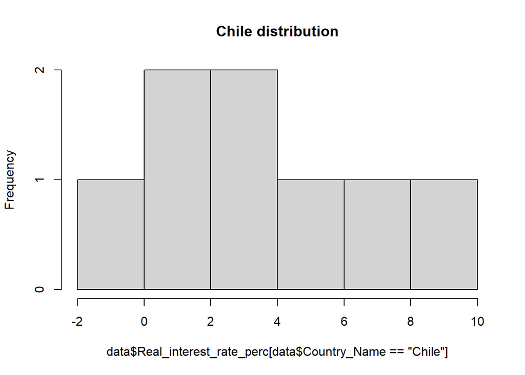

```r
hist(data$Real_interest_rate_perc[data$Country_Name=="Chile"],main = 'Chile distribution')
```

```r
shapiro.test(data$Real_interest_rate_perc[data$Country_Name=="Chile"])
```

```
##
##  Shapiro-Wilk normality test
##
## data:  data$Real_interest_rate_perc[data$Country_Name == "Chile"]
## W = 0.91289, p-value = 0.3748
```

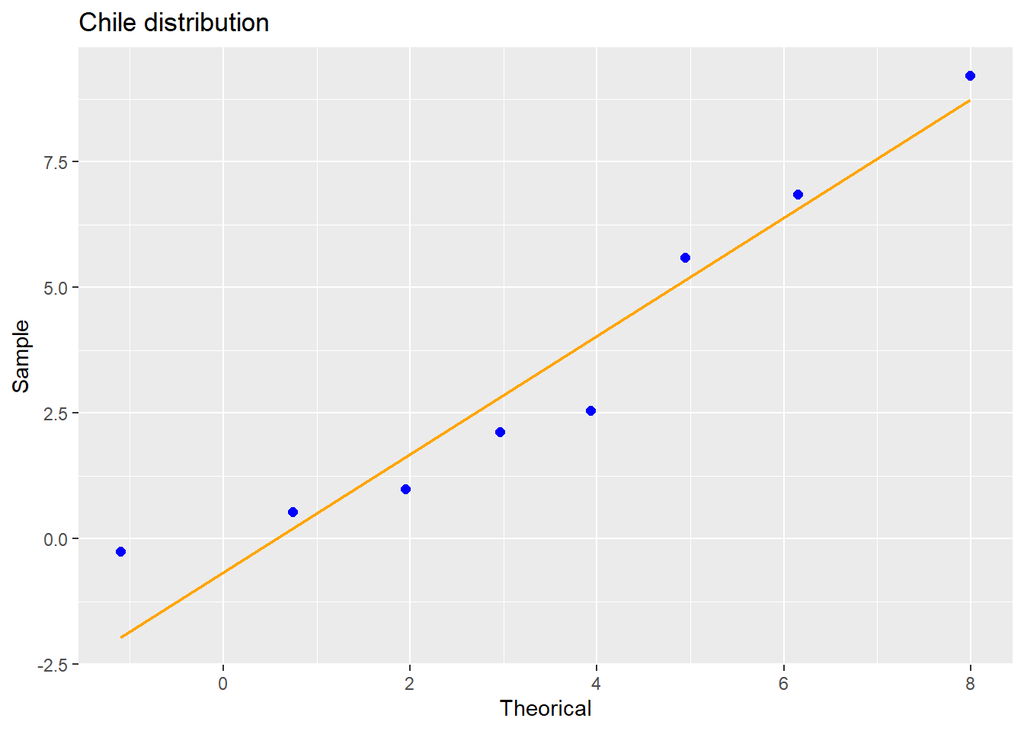

```r
ggplot(mapping=aes(sample=data$Real_interest_rate_perc[data$Country_Name=="Chile"]))+
  stat_qq_point(size=2,color='blue')+
  stat_qq_line(color='orange')+
  xlab('Theorical')+
  ylab('Sample')+
  ggtitle('Chile distribution')
```

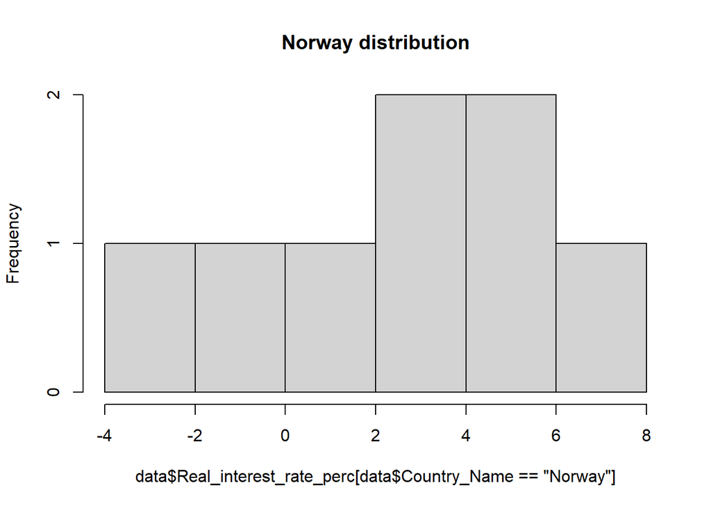

```r
hist(data$Real_interest_rate_perc[data$Country_Name=="Norway"],main = 'Norway distribution')
```

```r
shapiro.test(data$Real_interest_rate_perc[data$Country_Name=="Norway"])
```

```
##
##  Shapiro-Wilk normality test
##
## data:  data$Real_interest_rate_perc[data$Country_Name == "Norway"]
## W = 0.90438, p-value = 0.3162
```

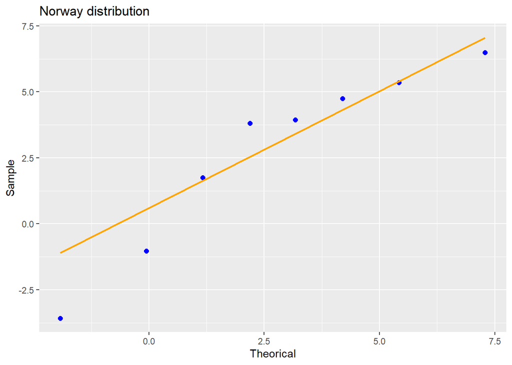

```r
ggplot(mapping=aes(sample=data$Real_interest_rate_perc[data$Country_Name=="Norway"]))+
  stat_qq_point(size=2,color='blue')+
  stat_qq_line(color='orange')+
  xlab('Theorical')+
  ylab('Sample')+
  ggtitle('Norway distribution')
```

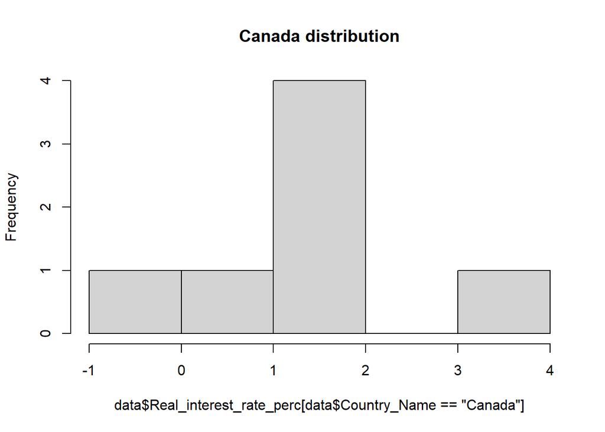

```r
hist(data$Real_interest_rate_perc[data$Country_Name=="Canada"],main = 'Canada distribution')
```

```r
shapiro.test(data$Real_interest_rate_perc[data$Country_Name=="Canada"])
```

```
##
##  Shapiro-Wilk normality test
##
## data:  data$Real_interest_rate_perc[data$Country_Name == "Canada"]
## W = 0.94839, p-value = 0.715
```

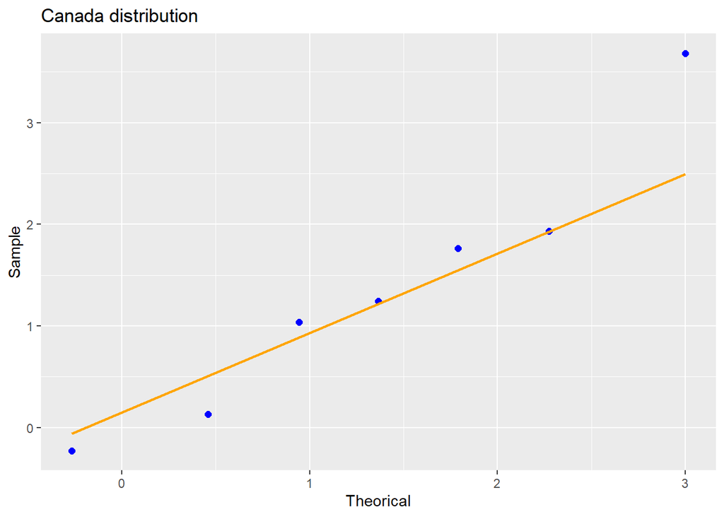

```r
ggplot(mapping=aes(sample=data$Real_interest_rate_perc[data$Country_Name=="Canada"]))+
  stat_qq_point(size=2,color='blue')+
  stat_qq_line(color='orange')+
  xlab('Theorical')+
  ylab('Sample')+
  ggtitle('Canada distribution')
```

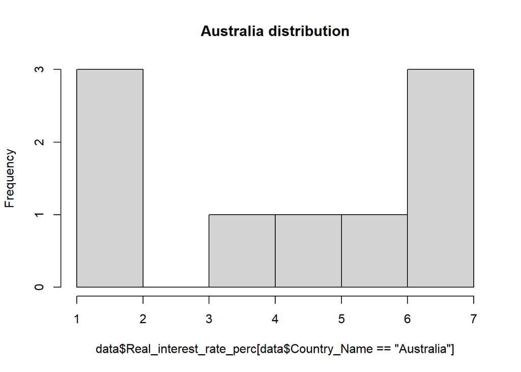

```r
hist(data$Real_interest_rate_perc[data$Country_Name=="Australia"],main = 'Australia distribution')
```

```r
shapiro.test(data$Real_interest_rate_perc[data$Country_Name=="Australia"])
```

```
##
##  Shapiro-Wilk normality test
##
## data:  data$Real_interest_rate_perc[data$Country_Name == "Australia"]
## W = 0.8552, p-value = 0.08498
```

[figure not shown]

```r
ggplot(mapping=aes(sample=data$Real_interest_rate_perc[data$Country_Name=="Austarlia"]))+
  stat_qq_point(size=2,color='blue')+
  stat_qq_line(color='orange')+
  xlab('Theorical')+
  ylab('Sample')+
  ggtitle('Australia distribution')
```

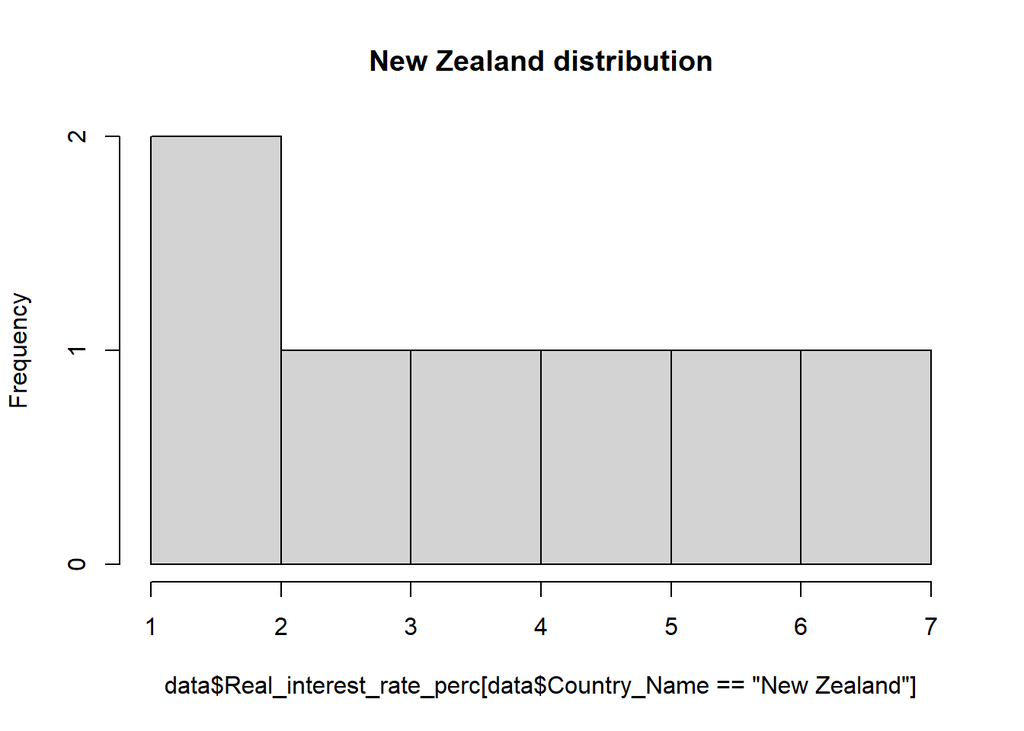

```r
hist(data$Real_interest_rate_perc[data$Country_Name=="New Zealand"],main = 'New Zealand distribution')
```

```r
shapiro.test(data$Real_interest_rate_perc[data$Country_Name=="New Zealand"])
```

```
##
##  Shapiro-Wilk normality test
##
## data:  data$Real_interest_rate_perc[data$Country_Name == "New Zealand"]
## W = 0.93695, p-value = 0.6114
```

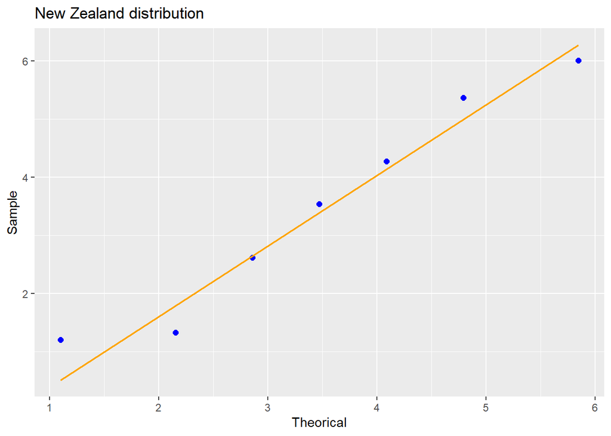

```r
ggplot(mapping=aes(sample=data$Real_interest_rate_perc[data$Country_Name=="New Zealand"]))+
  stat_qq_point(size=2,color='blue')+
  stat_qq_line(color='orange')+
  xlab('Theorical')+
  ylab('Sample')+
  ggtitle('New Zealand distribution')
```

The distribution for all of the countries that include missing data in Real interest rate is approximatly normal distributed(looking at histogram, shapyro test and ggplot) thus I’ll use the mean of real interest rate for each country to replace the corrispective missing value

```r
#Chile
data$Real_interest_rate_perc[data$Country_Name=='Chile'][is.na(data$Real_interest_rate_perc[data$Country_Name=='Chile'])] = mean(data$Real_interest_rate_perc[data$Country_Name=='Chile'] ,na.rm= TRUE)
#Norway
data$Real_interest_rate_perc[data$Country_Name=='Norway'][is.na(data$Real_interest_rate_perc[data$Country_Name=='Norway'])] = mean(data$Real_interest_rate_perc[data$Country_Name=='Norway'] ,na.rm= TRUE)
#Canada
data$Real_interest_rate_perc[data$Country_Name=='Canada'][is.na(data$Real_interest_rate_perc[data$Country_Name=='Canada'])] = mean(data$Real_interest_rate_perc[data$Country_Name=='Canada'] ,na.rm= TRUE)
#Australia
data$Real_interest_rate_perc[data$Country_Name=='Australia'][is.na(data$Real_interest_rate_perc[data$Country_Name=='Australia'])] = mean(data$Real_interest_rate_perc[data$Country_Name=='Australia'] ,na.rm= TRUE)
#New Zealand
data$Real_interest_rate_perc[data$Country_Name=='New Zealand'][is.na(data$Real_interest_rate_perc[data$Country_Name=='New Zealand'])] = mean(data$Real_interest_rate_perc[data$Country_Name=='New Zealand'] ,na.rm= TRUE)

is.na(data$Real_interest_rate_perc)
```

```
##   [1] FALSE FALSE FALSE FALSE FALSE FALSE FALSE FALSE FALSE FALSE FALSE FALSE
##  [13] FALSE FALSE FALSE FALSE FALSE FALSE FALSE FALSE FALSE FALSE FALSE FALSE
##  [25] FALSE FALSE FALSE FALSE FALSE FALSE FALSE FALSE FALSE FALSE FALSE FALSE
##  [37] FALSE FALSE FALSE FALSE FALSE FALSE FALSE FALSE FALSE FALSE FALSE FALSE
##  [49] FALSE FALSE FALSE FALSE FALSE FALSE FALSE FALSE FALSE FALSE FALSE FALSE
##  [61] FALSE FALSE FALSE FALSE FALSE FALSE FALSE FALSE FALSE FALSE FALSE FALSE
##  [73] FALSE FALSE FALSE FALSE FALSE FALSE FALSE FALSE FALSE FALSE FALSE FALSE
##  [85] FALSE FALSE FALSE FALSE FALSE FALSE FALSE FALSE FALSE FALSE FALSE FALSE
##  [97] FALSE FALSE FALSE FALSE FALSE FALSE FALSE FALSE FALSE FALSE FALSE FALSE
## [109] FALSE FALSE FALSE FALSE FALSE FALSE FALSE FALSE FALSE FALSE FALSE FALSE
```

```r
#checked that there are no missing values in the Real interest rate column
```

*So we have now a dataset with no missing values*

Let’s now check for data distribution and possible outliers:

```r
colnames(data)
```

```
##  [1] "Country_Name"
##  [2] "Country_Code"
##  [3] "Time"
##  [4] "Access_to_electricity._percentage_of_pop"
##  [5] "Life_expectancy_at_birth"
##  [6] "Mortality_rate_under_5_per_1.000_live_births"
##  [7] "Political_Stability.Absence_of_Violence.Terrorism._Percentile_R"
##  [8] "Population_total"
##  [9] "Real_interest_rate_perc"
## [10] "Consumer_price_index_2010._100"
## [11] "GDP_US."
```

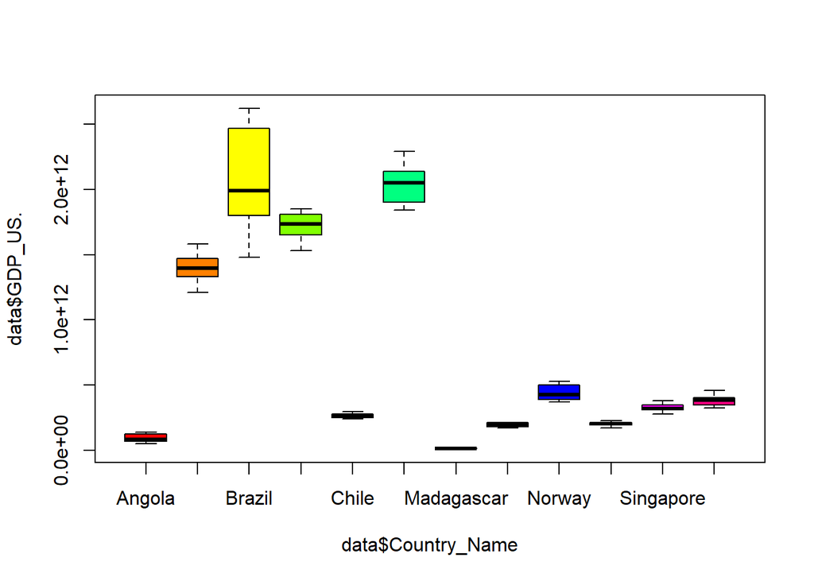

```r
boxplot(data$GDP_US.~data$Country_Name,col=(rainbow(12)))
```

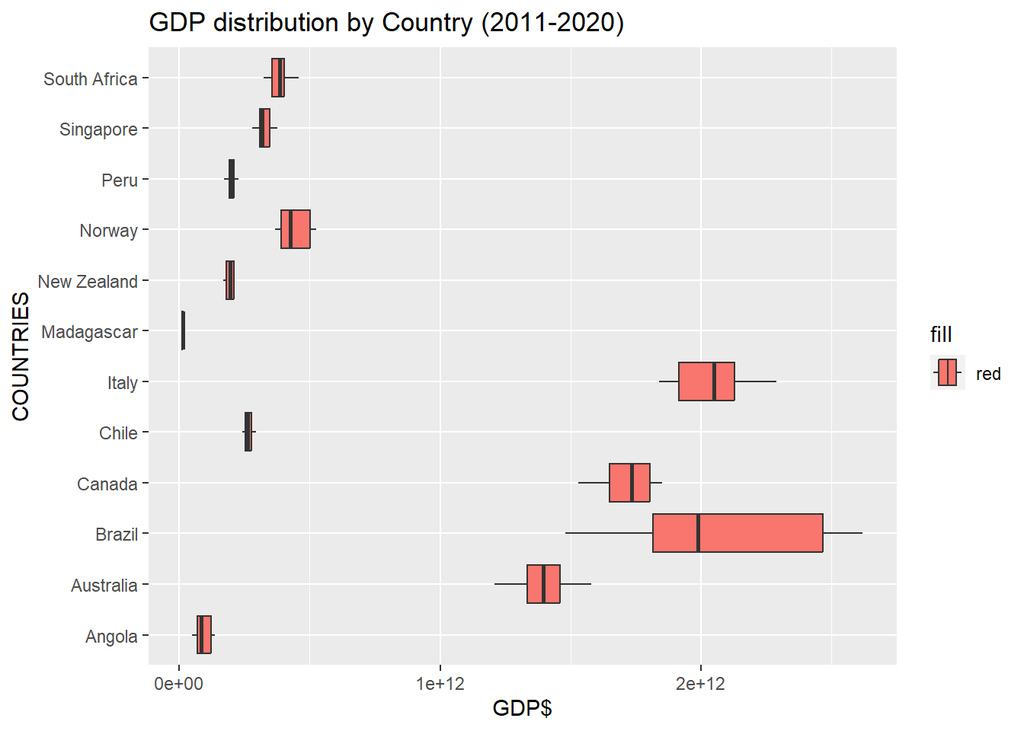

```r
qplot(GDP_US.,Country_Name,geom='boxplot',data =data,fill='red')+
    labs(title = "GDP distribution by Country (2011-2020)")+
  xlab('GDP$')+
  ylab('COUNTRIES')
```

From the boxplot Brazil and italy have a big variation and possibly outliers. Let’s indagate further:

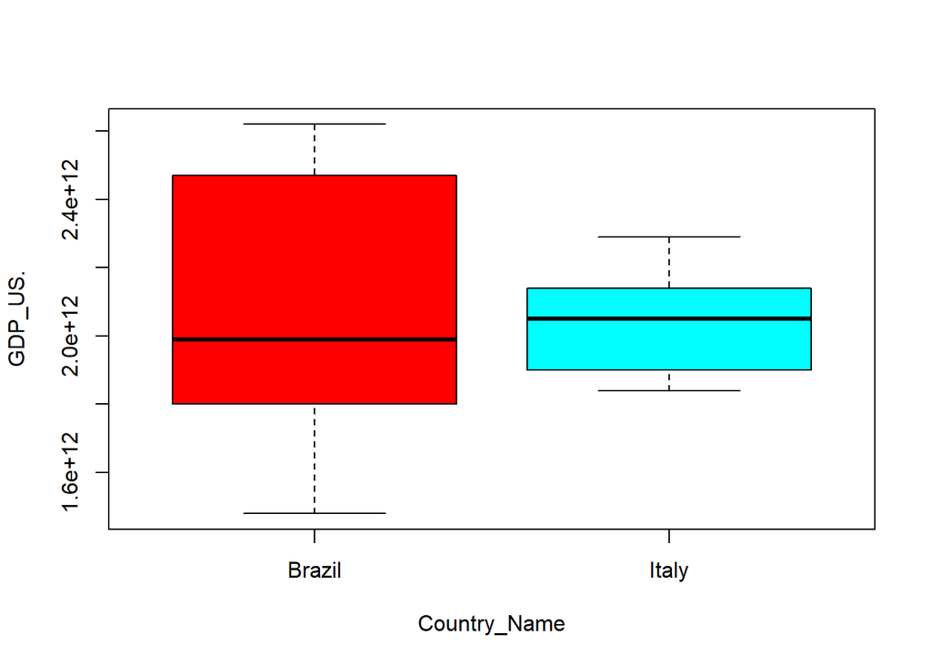

```r
boxplot(GDP_US.~Country_Name,data=data,col=(rainbow(2)),
        subset = Country_Name%in% c('Italy','Brazil'))
```

```r
options(scipen = 999, digits = 20)
data$GDP_US.[data$Country_Name=='Brazil']
```

```
##  [1] 2620000000000 2470000000000 2470000000000 2460000000000 1800000000000
##  [6] 1800000000000 2060000000000 1920000000000 1870000000000 1480000000000
```

**The variation can be attributed to Brazil’s dynamic economy.”** same for italy

*Next step, I’ll divide the countries between developed and developing. A reasonable approch is to calculate the GDP PER CAPITA, DEFINE A TRESHHOLD AND DIVIDE THE 2 GROUPS:

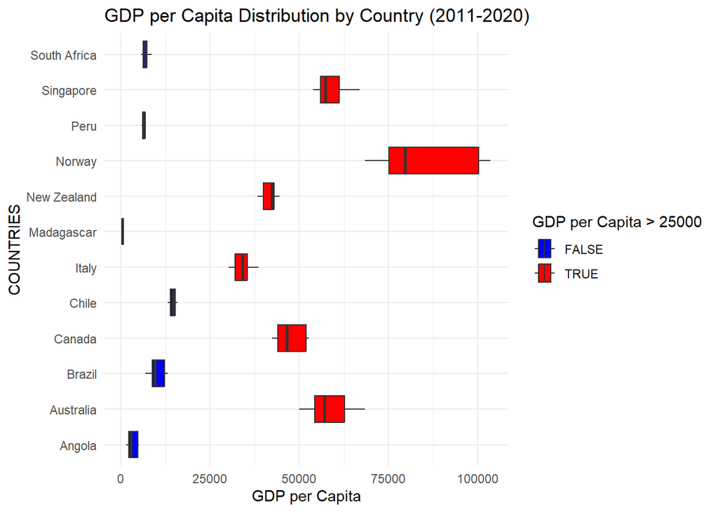

```r
data$GDP_per_Capita = data$GDP_US. / data$Population_total

ggplot(data = data, aes(x = GDP_per_Capita, y = Country_Name, fill = factor(GDP_per_Capita > 25000))) +
  geom_boxplot() +
  labs(title = "GDP per Capita Distribution by Country (2011-2020)",
       x = "GDP per Capita",
       y = "COUNTRIES") +
  scale_fill_manual(values = c("TRUE" = "red", "FALSE" = "blue"),
                    guide = guide_legend(title = "GDP per Capita > 25000")) +
  theme_minimal()
```

We can visualize which one are the developed country and developing ones from the plot above given a threshold of 25000

*divide the 2 gropus:*

```r
developed_countries = data %>%
  filter(Country_Name %in% c('Australia', 'Canada', 'Italy', 'Norway', 'Singapore','New Zealand')) %>%
  group_by(Country_Name, Time)
developed_countries=as.data.frame(developed_countries)
```

```r
developing_countries = data %>%
  filter(Country_Name %in% c("Angola","Madagascar","South Africa","Brazil","Chile","Peru")) %>%
  group_by(Country_Name, Time)
developing_countries=as.data.frame(developing_countries)
```

*I’ll now do some descriptive stat between developed and developing countries:

```r
summary(developed_countries)
```

```
##  Country_Name       Country_Code            Time
##  Length:60          Length:60          Min.   :2011.0
##  Class :character   Class :character   1st Qu.:2013.0
##  Mode  :character   Mode  :character   Median :2015.5
##                                        Mean   :2015.5
##                                        3rd Qu.:2018.0
##                                        Max.   :2020.0
##  Access_to_electricity._percentage_of_pop Life_expectancy_at_birth
##  Min.   :100                              Min.   :81.156097560000006
##  1st Qu.:100                              1st Qu.:81.776097557499995
##  Median :100                              Median :82.233902439999994
##  Mean   :100                              Mean   :82.308422764300005
##  3rd Qu.:100                              3rd Qu.:82.751219515000003
##  Max.   :100                              Max.   :84.465853659999993
##  Mortality_rate_under_5_per_1.000_live_births
##  Min.   :2.2000000000000002
##  1st Qu.:2.7999999999999998
##  Median :3.7999999999999998
##  Mean   :3.9133333333300002
##  3rd Qu.:5.2000000000000002
##  Max.   :6.0999999999999996
##  Political_Stability.Absence_of_Violence.Terrorism._Percentile_R
##  Min.   :57.075469970000000
##  1st Qu.:80.778303142499993
##  Median :89.858489989999995
##  Mean   :85.880968411300003
##  3rd Qu.:97.156394960000000
##  Max.   :99.523811339999995
##  Population_total             Real_interest_rate_perc
##  Min.   : 4384000.000000000   Min.   :-3.5759665570000001
##  1st Qu.: 5187377.250000000   1st Qu.: 1.6341878265000001
##  Median :14021796.500000000   Median : 3.2689512485000001
##  Mean   :22603427.333299998   Mean   : 3.1120326609900002
##  3rd Qu.:35804552.750000000   3rd Qu.: 4.5314245025000002
##  Max.   :60789140.000000000   Max.   : 8.1666652909999993
##  Consumer_price_index_2010._100    GDP_US.
##  Min.   :101.28495160000000     Min.   : 168000000000
##  1st Qu.:106.97974785000000     1st Qu.: 318000000000
##  Median :110.30224180000000     Median : 868000000000
##  Mean   :110.49724391800000     Mean   :1019616666670
##  3rd Qu.:113.91021815000001     3rd Qu.:1732500000000
##  Max.   :121.81703010000000     Max.   :2290000000000
##  GDP_per_Capita
##  Min.   : 30297.750151600001
##  1st Qu.: 42239.630855800002
##  Median : 52421.483511699997
##  Mean   : 54378.748242299996
##  3rd Qu.: 62630.432089900001
##  Max.   :103550.991875000007
```

**Descriptive stats on all the data:**

```r
describe(data)
```

```
##                                                                 vars   n
## Country_Name*                                                      1 120
## Country_Code*                                                      2 120
## Time                                                               3 120
## Access_to_electricity._percentage_of_pop                           4 120
## Life_expectancy_at_birth                                           5 120
## Mortality_rate_under_5_per_1.000_live_births                       6 120
## Political_Stability.Absence_of_Violence.Terrorism._Percentile_R    7 120
## Population_total                                                   8 120
## Real_interest_rate_perc                                            9 120
## Consumer_price_index_2010._100                                    10 120
## GDP_US.                                                           11 120
## GDP_per_Capita                                                    12 120
##                                                                                             mean
## Country_Name*                                                              6.5000000000000000000
## Country_Code*                                                              6.5000000000000000000
## Time                                                                    2015.5000000000000000000
## Access_to_electricity._percentage_of_pop                                  86.9200000000000017053
## Life_expectancy_at_birth                                                  76.0199999999999960210
## Mortality_rate_under_5_per_1.000_live_births                              21.4100000000000001421
## Political_Stability.Absence_of_Violence.Terrorism._Percentile_R           61.6599999999999965894
## Population_total                                                    41705031.7999999970197677612
## Real_interest_rate_perc                                                    9.9100000000000001421
## Consumer_price_index_2010._100                                           129.8300000000000125056
## GDP_US.                                                         763980978155.6600341796875000000
## GDP_per_Capita                                                         30692.5900000000001455192
##                                                                                               sd
## Country_Name*                                                              3.4700000000000001954
## Country_Code*                                                              3.4700000000000001954
## Time                                                                       2.8799999999999998934
## Access_to_electricity._percentage_of_pop                                  25.2600000000000015632
## Life_expectancy_at_birth                                                   8.0899999999999998579
## Mortality_rate_under_5_per_1.000_live_births                              27.6499999999999985789
## Political_Stability.Absence_of_Violence.Terrorism._Percentile_R           27.3000000000000007105
## Population_total                                                    52667372.4200000017881393433
## Real_interest_rate_perc                                                   14.0000000000000000000
## Consumer_price_index_2010._100                                            49.2899999999999991473
## GDP_US.                                                         779372213091.2900390625000000000
## GDP_per_Capita                                                         27135.1300000000010186341
##                                                                                           median
```

[output cut: 101 more lines]

```
## GDP_US.                                                         -0.90000000000000002220
## GDP_per_Capita                                                  -0.47999999999999998224
##                                                                                               se
## Country_Name*                                                             0.32000000000000000666
## Country_Code*                                                             0.32000000000000000666
## Time                                                                      0.26000000000000000888
## Access_to_electricity._percentage_of_pop                                  2.31000000000000005329
## Life_expectancy_at_birth                                                  0.73999999999999999112
## Mortality_rate_under_5_per_1.000_live_births                              2.52000000000000001776
## Political_Stability.Absence_of_Violence.Terrorism._Percentile_R           2.49000000000000021316
## Population_total                                                    4807851.32000000029802322388
## Real_interest_rate_perc                                                   1.28000000000000002665
## Consumer_price_index_2010._100                                            4.50000000000000000000
## GDP_US.                                                         71146623633.80000305175781250000
## GDP_per_Capita                                                         2477.09000000000014551915
```

```r
mode(data$Access_to_electricity._percentage_of_pop)
```

```
## [1] "numeric"
```

**Visualize it:**

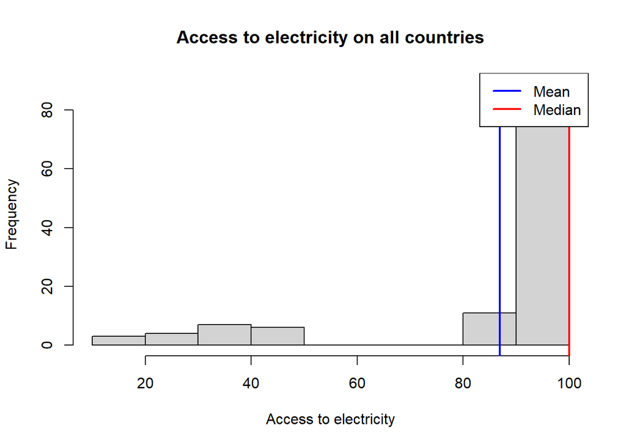

```r
#  histogram with mean, median
hist(data$Access_to_electricity._percentage_of_pop, breaks = 8, main = "Access to electricity on all countries",
     xlab = "Access to electricity", ylab = "Frequency")
abline(v = mean(data$Access_to_electricity._percentage_of_pop), col = "blue", lwd = 2)
abline(v = median(data$Access_to_electricity._percentage_of_pop), col = "red", lwd = 2)
legend("topright", legend = c("Mean", "Median"), col = c("blue", "red"), lwd = 2)
```

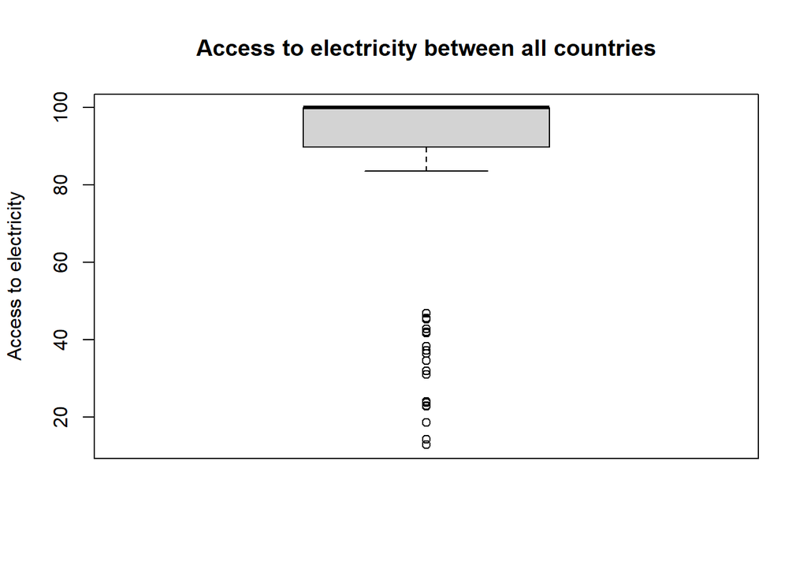

```r
#  boxplot
  boxplot(data$Access_to_electricity._percentage_of_pop, main = "Access to electricity between all countries",
        ylab = "Access to electricity")
```

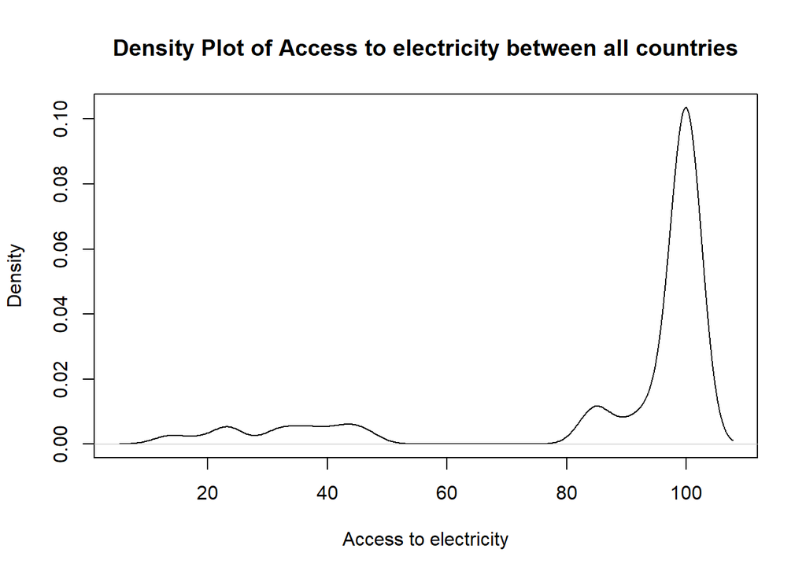

```r
# Create a density plot

plot(density(data$Access_to_electricity._percentage_of_pop), main = "Density Plot of Access to electricity between all countries",
     xlab = "Access to electricity", ylab = "Density")
```

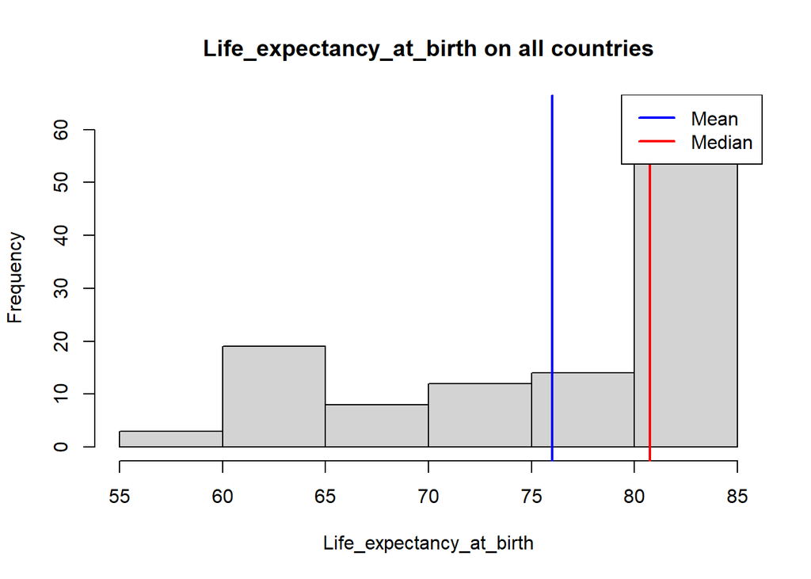

```r
#  histogram with mean, median
hist(data$Life_expectancy_at_birth, breaks = 8, main = "Life_expectancy_at_birth on all countries",
     xlab = "Life_expectancy_at_birth", ylab = "Frequency")
abline(v = mean(data$Life_expectancy_at_birth), col = "blue", lwd = 2)
abline(v = median(data$Life_expectancy_at_birth), col = "red", lwd = 2)
legend("topright", legend = c("Mean", "Median"), col = c("blue", "red"), lwd = 2)
```

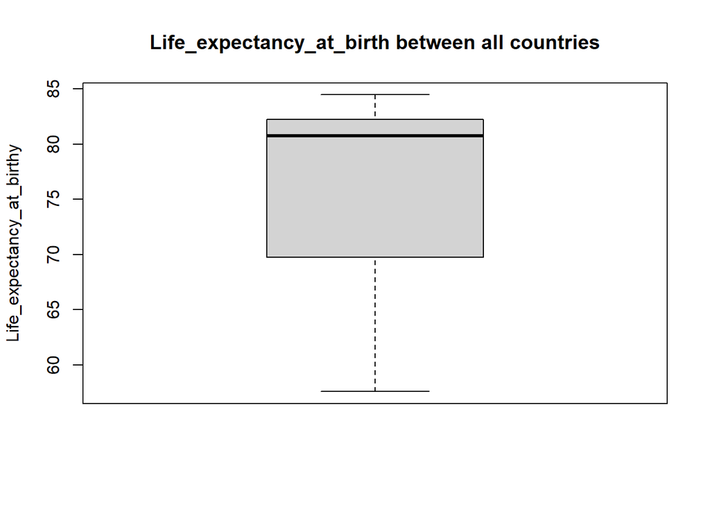

```r
#  boxplot
  boxplot(data$Life_expectancy_at_birth, main = "Life_expectancy_at_birth between all countries",
        ylab = "Life_expectancy_at_birthy")
```

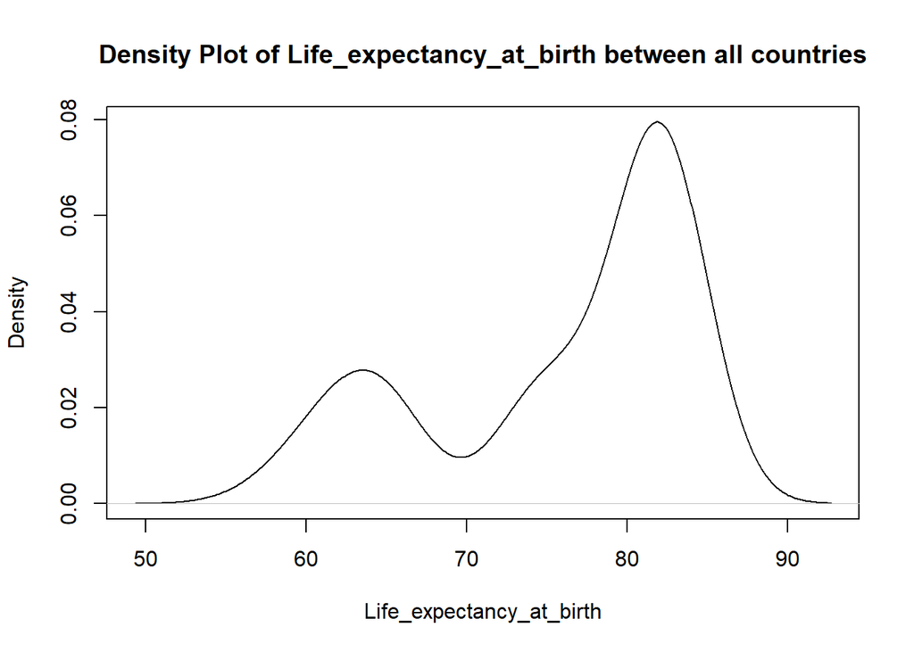

```r
# Create a density plot

plot(density(data$Life_expectancy_at_birth), main = "Density Plot of Life_expectancy_at_birth between all countries",
     xlab = "Life_expectancy_at_birth", ylab = "Density")
```

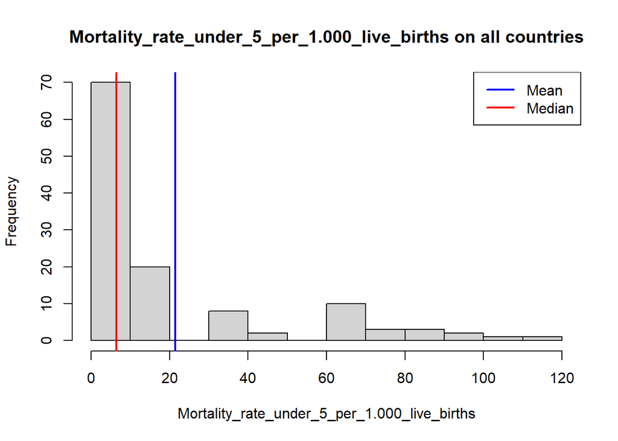

```r
#  histogram with mean, median
hist(data$Mortality_rate_under_5_per_1.000_live_births, breaks = 8, main = "Mortality_rate_under_5_per_1.000_live_births on all countries",
     xlab = "Mortality_rate_under_5_per_1.000_live_births", ylab = "Frequency")
abline(v = mean(data$Mortality_rate_under_5_per_1.000_live_births), col = "blue", lwd = 2)
abline(v = median(data$Mortality_rate_under_5_per_1.000_live_births), col = "red", lwd = 2)
legend("topright", legend = c("Mean", "Median"), col = c("blue", "red"), lwd = 2)
```

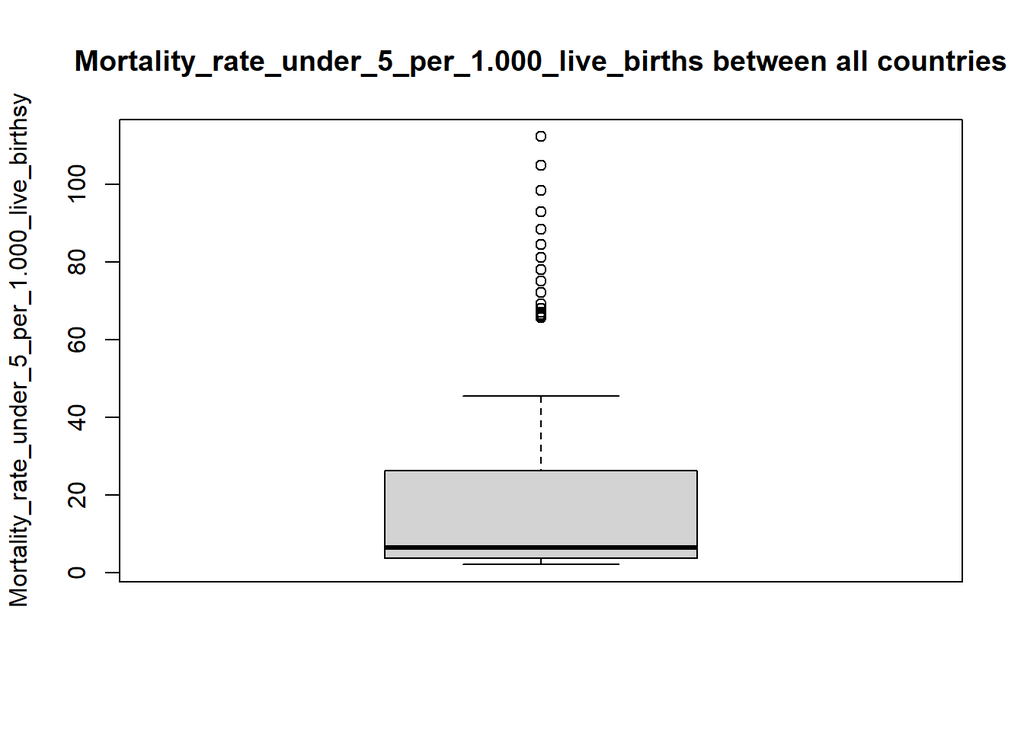

```r
#  boxplot
  boxplot(data$Mortality_rate_under_5_per_1.000_live_births, main = "Mortality_rate_under_5_per_1.000_live_births between all countries",
        ylab = "Mortality_rate_under_5_per_1.000_live_birthsy")
```

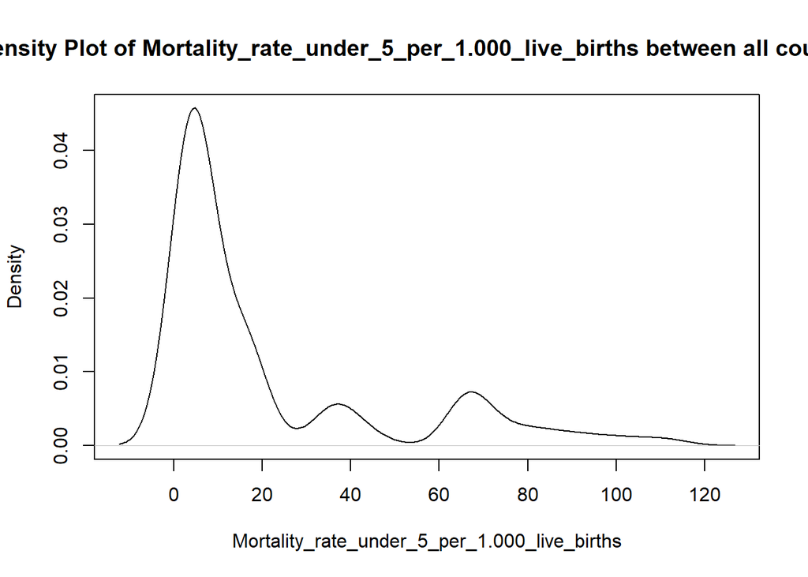

```r
# Create a density plot

plot(density(data$Mortality_rate_under_5_per_1.000_live_births), main = "Density Plot of Mortality_rate_under_5_per_1.000_live_births between all countries",
     xlab = "Mortality_rate_under_5_per_1.000_live_births", ylab = "Density")
```

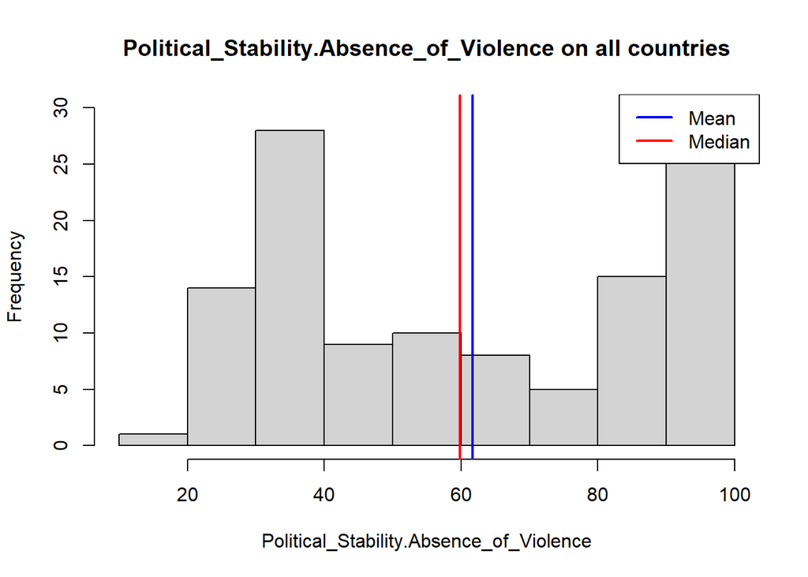

```r
#  histogram with mean, median
hist(data$Political_Stability.Absence_of_Violence.Terrorism._Percentile_R, breaks = 8, main = "Political_Stability.Absence_of_Violence on all countries",
     xlab = "Political_Stability.Absence_of_Violence", ylab = "Frequency")
abline(v = mean(data$Political_Stability.Absence_of_Violence.Terrorism._Percentile_R), col = "blue", lwd = 2)
abline(v = median(data$Political_Stability.Absence_of_Violence.Terrorism._Percentile_R), col = "red", lwd = 2)
legend("topright", legend = c("Mean", "Median"), col = c("blue", "red"), lwd = 2)
```

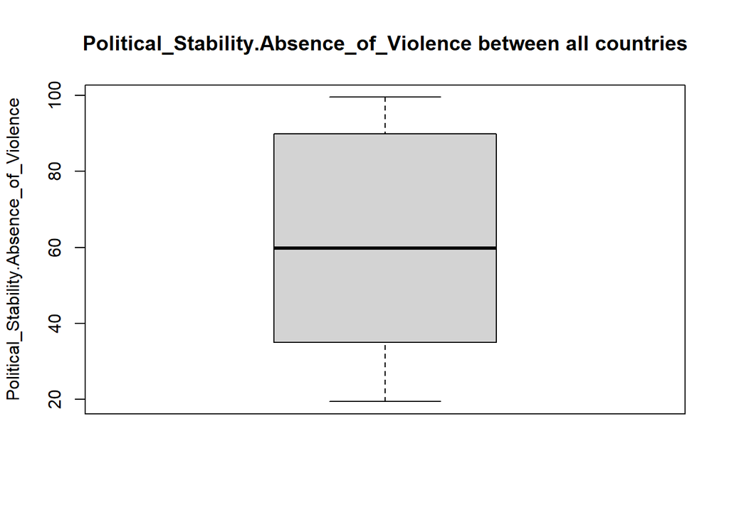

```r
#  boxplot
  boxplot(data$Political_Stability.Absence_of_Violence.Terrorism._Percentile_R, main = "Political_Stability.Absence_of_Violence between all countries",
        ylab = "Political_Stability.Absence_of_Violence")
```

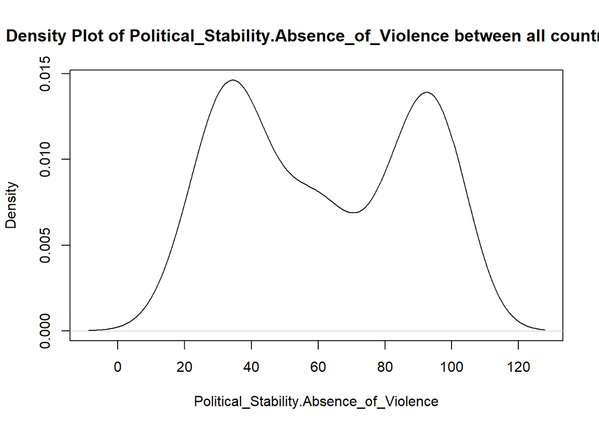

```r
# Create a density plot

plot(density(data$Political_Stability.Absence_of_Violence.Terrorism._Percentile_R), main = "Density Plot of Political_Stability.Absence_of_Violence between all countries",
     xlab = "Political_Stability.Absence_of_Violence", ylab = "Density")
```

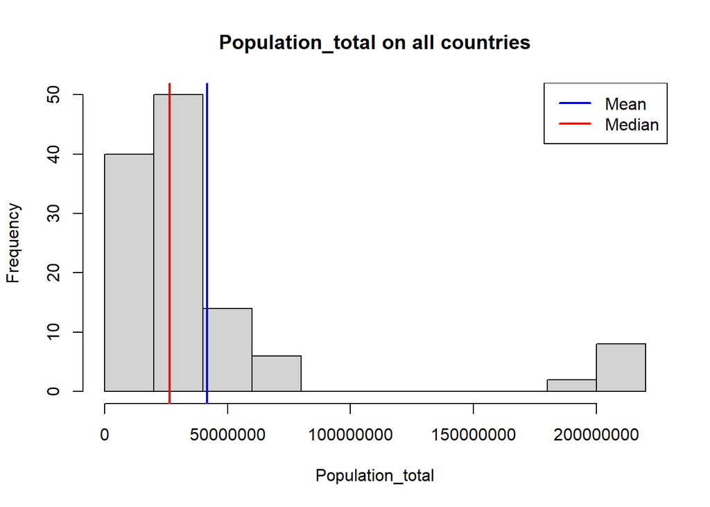

```r
#  histogram with mean, median
hist(data$Population_total, breaks = 8, main = "Population_total on all countries",
     xlab = "Population_total", ylab = "Frequency")
abline(v = mean(data$Population_total), col = "blue", lwd = 2)
abline(v = median(data$Population_total), col = "red", lwd = 2)
legend("topright", legend = c("Mean", "Median"), col = c("blue", "red"), lwd = 2)
```

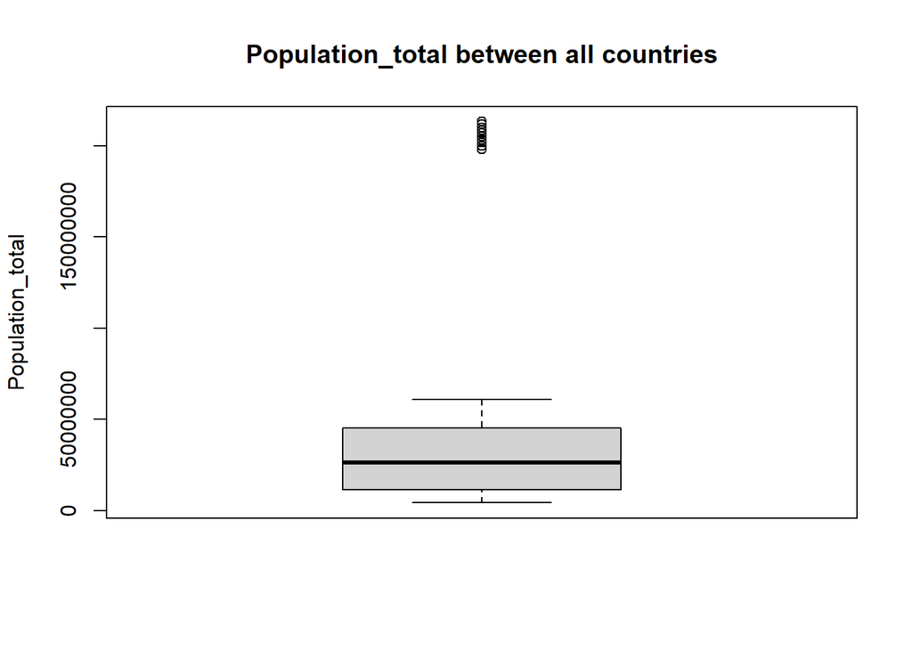

```r
#  boxplot
  boxplot(data$Population_total, main = "Population_total between all countries",
        ylab = "Population_total")
```

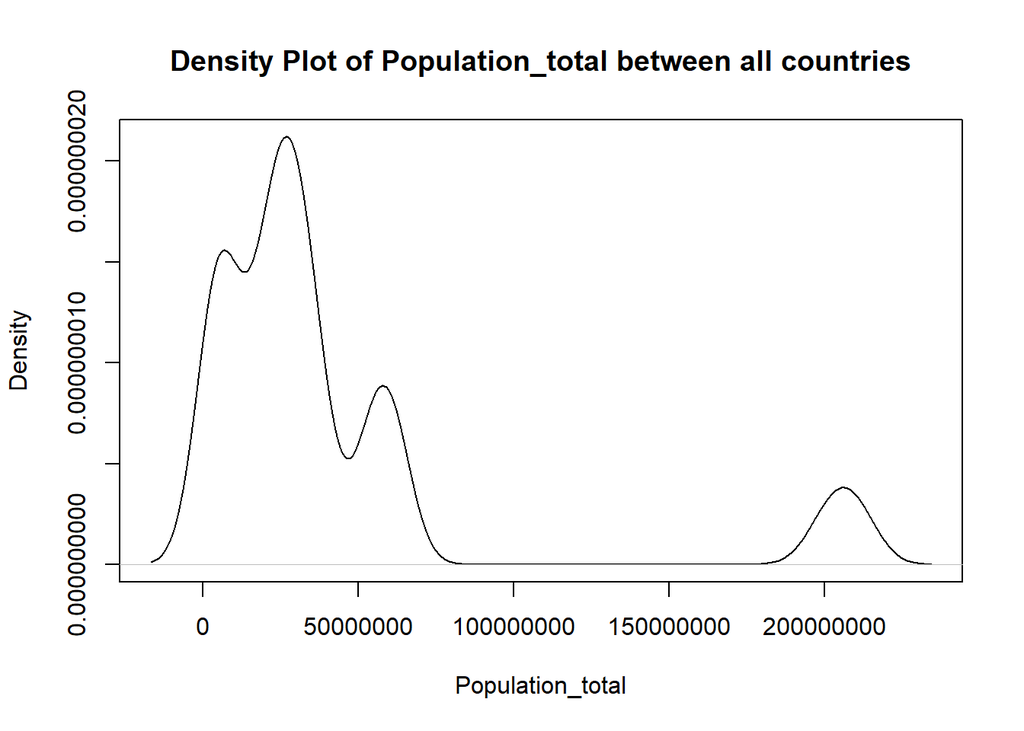

```r
# Create a density plot

plot(density(data$Population_total), main = "Density Plot of Population_total between all countries",
     xlab = "Population_total", ylab = "Density")
```

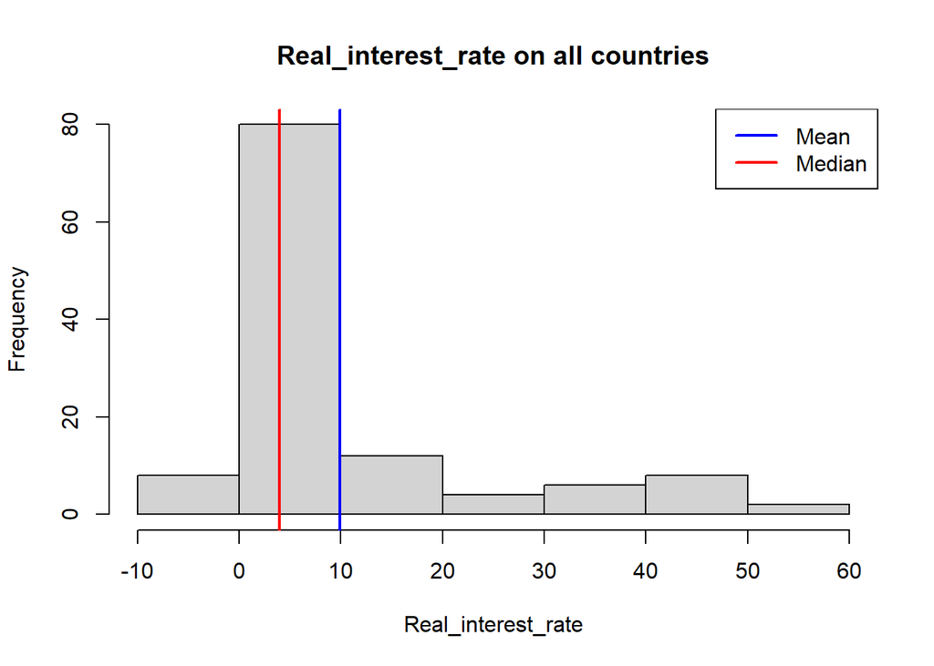

```r
#  histogram with mean, median
hist(data$Real_interest_rate_perc, breaks = 8, main = "Real_interest_rate on all countries",
     xlab = "Real_interest_rate", ylab = "Frequency")
abline(v = mean(data$Real_interest_rate_perc), col = "blue", lwd = 2)
abline(v = median(data$Real_interest_rate_perc), col = "red", lwd = 2)
legend("topright", legend = c("Mean", "Median"), col = c("blue", "red"), lwd = 2)
```